# ~ Pittsburgh Flight Data Explanatory Analysis ~

## An Explanatory Analysis of Delayed Flights in Pittsburgh, PA in 2007

*Created by Miles Murphy*

*November 11, 2020*

## Project Background:

This explanatory data analysis is part of the larger Udacity Data Analyst Nanodegree. The final project for the Data Visualization process involves the exploratory and explanatory analysis of a dataset. US Flight data was one of the provided options.

### Exploratory Analysis Summary

#### Analysis Steps

The exploratory analysis consisted of data wrangling and visualization steps detailed below:

1. Two years worth of flight data were imported into two separate dataframes for 1988 and 2007. They were then quickly analyzed to determine basic information about each
2. Based on the quick assessment of each dataframe, and the intended research goals of examining flights only related to Pittsburgh, the dataframes were then cleaned to correct quality/tidiness issues and select the specific data of interest
3. At the conclusion of these wrangling steps, a separate df consisting of just flights from 2007 which experienced one or more delay types (Carrier, Weather, NAS, Security, or Late Aircraft) was created for use in the explanatory analysis
4. Various visualizations were created utilizing the 1988 and 2007 Pittsburgh flight dataframes to pull out key insights and takeaways

#### Takeaways

The key takeaways from the exploratory visual analysis are the following (in no particular order):

- There were substantially more flights (over 2x more) in 1988 in Pittsburgh than in 2007
- Despite the vast difference in numbers, the overall pattern remained fairly consistent when looking at flight data by month or by day of the week
- Summer travel was preferred over the Winter months and February was the least preferred month to travel
- Weekdays were preferred for travel over weekends and Saturday was the least favorite day for a flight
- Late Aircraft delays caused many delays for flights in and out of Pittsburgh in 2007
- No day of the week saw a lot more total delay time when for the top 5 delay types, but unsurprisingly, weekdays experienced more total delay time than weekends - likely due to the increased travel
- NAS delays seemed to add more to the overall elapsed time despite usually being the lowest delay type

The full exploratory project contains additional insights beyond those detailed above.

## Explanatory Analysis

### Questions

The following are some of the questions which will be answered by this explanatory analysis to provide key insights into the dataframe

- What are the most popular month and day of the week to fly?
- How long are flights?
- How long are delay times
- What delay types cause the most delays?
- Does any month or day of the weeke experience more or less delay time?
- How do delay types vary between the destinations of Pittsburgh flights in 2007?

### Univariate Analysis

The first few figures will create some basic visualizations to show simple information about the dataset prior to the more detailed/insightful bivariate and multivariate analysis.

#### a. Most Popular Month to Fly

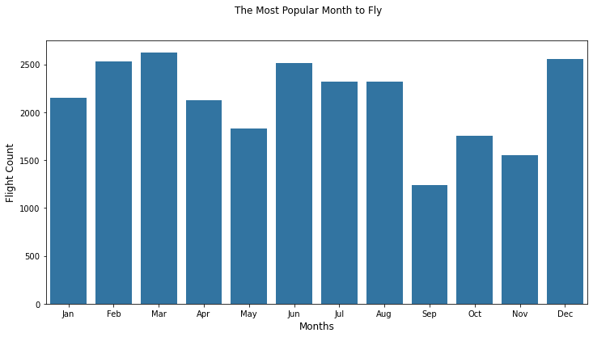

This figure shows the total flight count by month for flights with delays in Pittsburgh, PA in 2007. Several months had 2,000-2,500 flights and September was the lowest with only around 1,250.

#### b. Most Popular Day of the Week

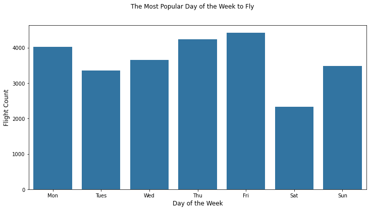

This figure showed the flight count by day of the week for flights to and from Pittsburgh PA in 2007 which experienced delays. Thursday and Friday were the most traveled days with over 4,000 flights and Saturday was the least traveled with only around 2,500 flights

#### c. Most Popular Flight Destinations and Origins

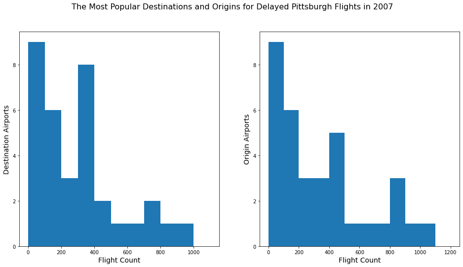

#### d. Flight Length and Delay Length

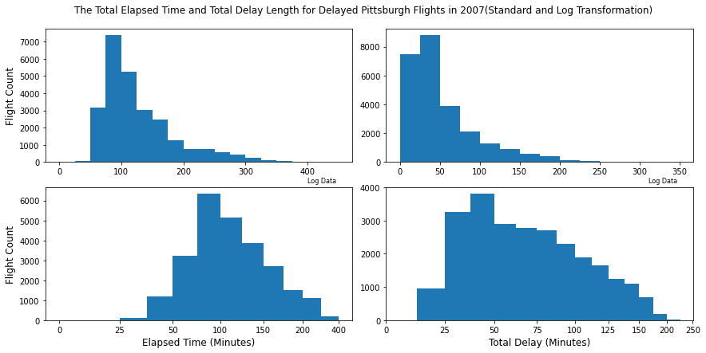

### Bivariate Analysis

#### a. Total Delay Time By Delay Type Combination

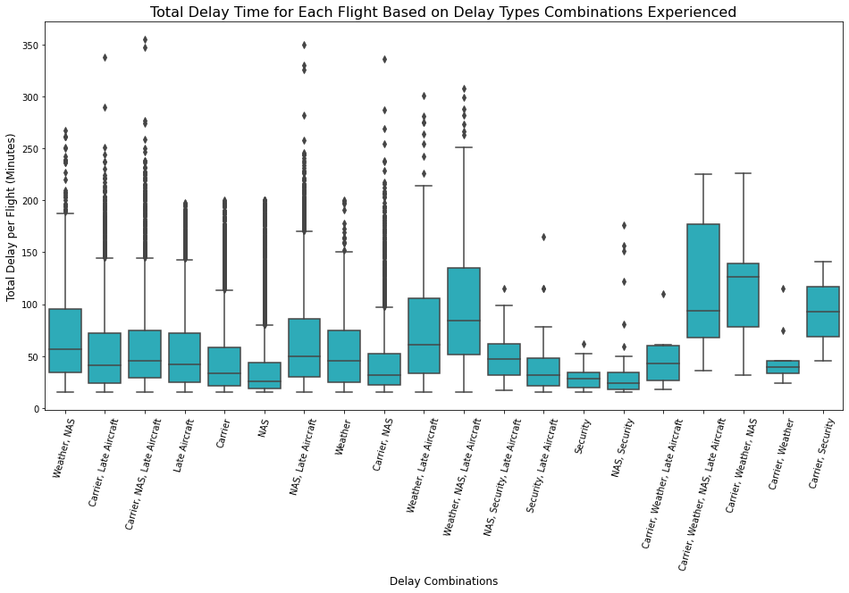

Most Delay Type combinations caused a flight to experience between approximately 25 minutes to 75 minutes of delays. Some delay types, such as the combinations with a Late Aircraft Delay, experienced higher total delay times with some exceeding 250 minutes

#### b. Total Delay Time by Days of the Week

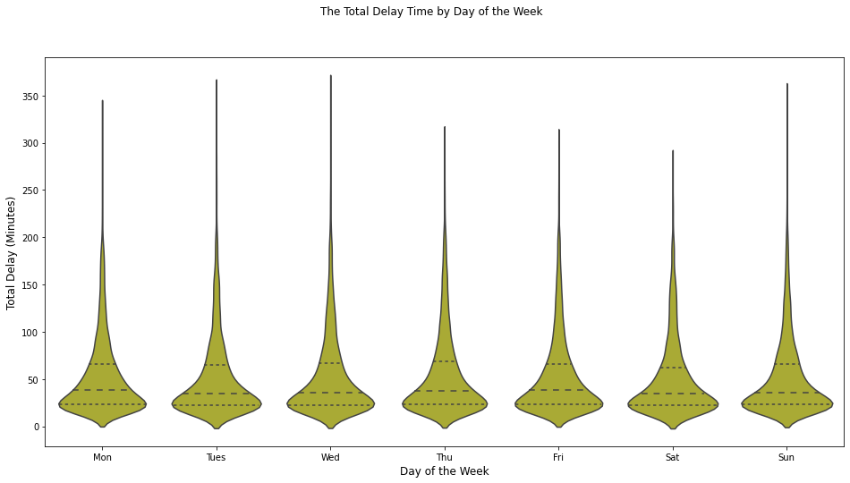

This figure shows that the Total Delay Time is fairly consistent by day of the week, with Saturday seeing lower totals than the other days.

#### c. Total Delay Time by Month

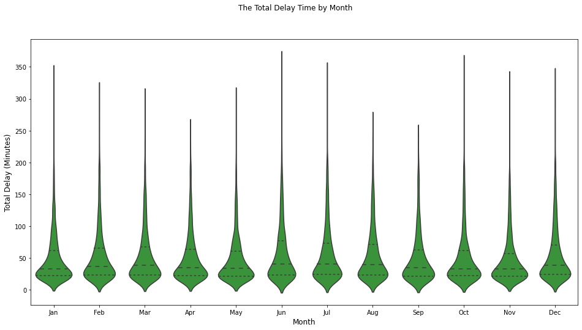

### Multivariate Analysis

Due to the high number of delay combinations, only the top 5 delay type combinations will be utilized for the following figures

#### a. Average Total Delay Time for the Day of the Week

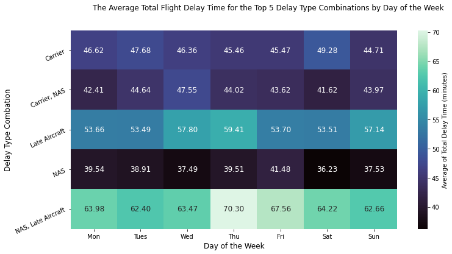

The above figure shows that the Delay Type Combination of 'NAS, Late Aircraft' lead to most delays by day of the week and 'NAS' alone lead to the least. Thursday was the most delayed day of the week by the top 5 delay types

#### b. Average Total Delay Time for Month

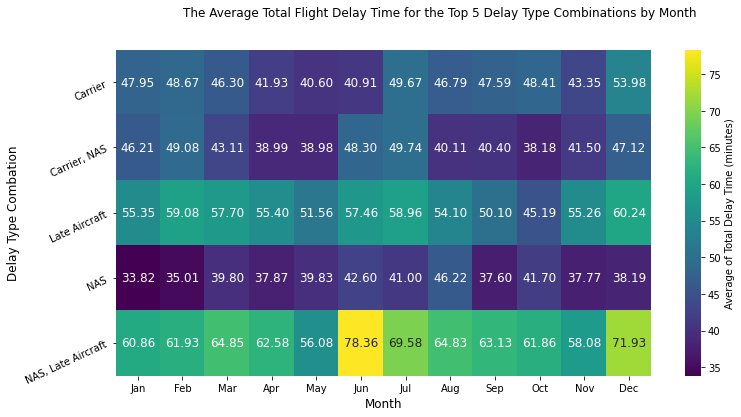

The figure looking at delay type combinations by month also has the 'NAS, Late Aircraft' delay combination leading to the highest average delay time in every month, with June experiencing almost an average of 80 minutes per 'NAS, Late Aircraft' delay

#### c. Total Elapsed Time and Delay Type for Flights Departing Pittsburgh

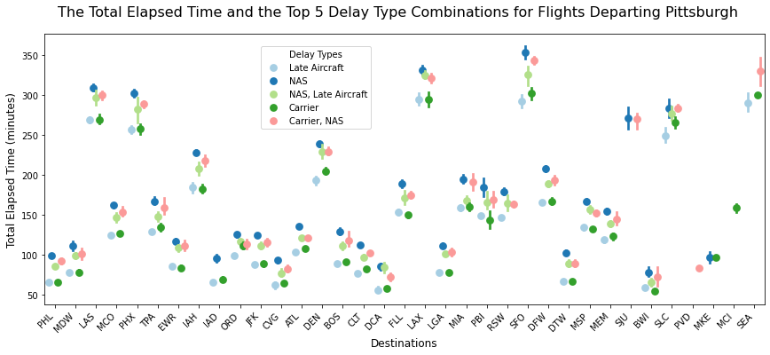

The above figure provides a lot of interesting insights, but the most may be that despite having the lowest Total Delay Times, NAS delays seem to add the most to Total Elapsed Time of flights.

## Explanatory Analysis Summary

#### Next Steps

There are many aspects of this dataframe, let alone the larger dataframes which need to be explored in greater detail.

1. Gain a better understanding of how each type of delay impacts the delaytime of a flight and the elapsed time of a flight
2. Examine the flights to and from massive hub airports (e.g. Atlanta, NYC, and Chicago) separately from those the smaller regional and local airports
3. Explore whether travel on Saturday is less preferred outside of this Pittsburgh delays df from 2007 - is it seen in every year?
4. And many, many more